# Kodutoo_1

Siim Põldre

2/16/2021

## R Markdown

Teistest eristuvad spetsiifiliselt rahvusvahelisi organisatsioone nimetavad küsimused, millel on kõige rohkem puuduvaid vastuseid. Kokku on 379 NA-d.

Puuduvad väärtused tunnuste lõikes

| Tunnus | Puuduvate arv | Valiidsete arv |
| --- | --- | --- |
| trstprl | 14 | 1890 |
| trstlgl | 27 | 1877 |
| trstplc | 6 | 1898 |
| trstplt | 19 | 1885 |
| trstprt | 23 | 1881 |
| trstep | 131 | 1773 |
| trstun | 153 | 1751 |
| gndr | 0 | 1904 |
| agea | 0 | 1904 |
| eduyrs | 0 | 1904 |
| rlgdgr | 6 | 1898 |
| brncntr | 0 | 1904 |
| Summa | 379 | 22469 |

Täisvastuste osakaal

[output not shown]

Näha on, et meeste seas on täisvastustega indiviidide osakaal mõneti suurem. See viitab täieliku juhuslikkuse puudumisele soo vaates.

Soo ja puuduvate väärtuste suhe

| Sugu | Valiidete osakaal |
| --- | --- |
| Female | 0.8744142 |
| Male | 0.9271207 |

Näha on, et täisvastustega indiviidide keskmine vanus on 49.66 aastat ja mitte-täisvastustega inimeste keskminevanus on 60.2 aastat. See viitab sellele, et vastamata jätavad keskmiselt vanemad inimesed ja taas täieliku juhuslikkuse puudumisele.

Vanuse ja puuduvate väärtuste suhe

| Valiidsus | Keskmine vanus |
| --- | --- |
| 0 | 60.15385 |
| 1 | 49.65535 |

Vaadates vanusegrupiti on samuti näha, et täisvastustega inimeste hulk langeb vanuse kasvades

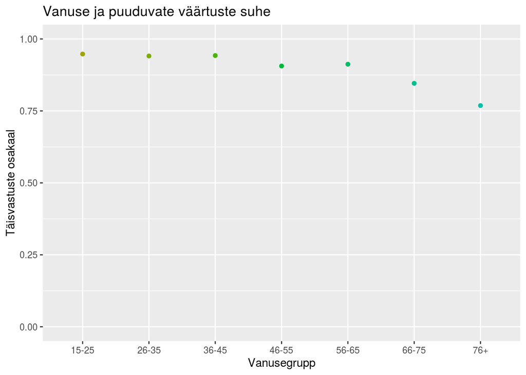

Siin on pandud objektid vanuse järjekorda ja on ka näha, et vanuse kasvades kasvab inimeste arv, kellel on puuduvaid väärtuseid

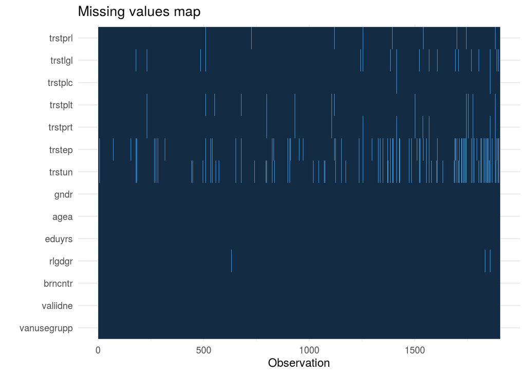

Vaadates religioossust tundub, et selget lineaarset mustrit pole religioossuse tõusu ja valiidsete vastuste osakaalu vahel. Samas on näha, et väga religiossete inimeste puhul on täielike vastuste määr kõige väiksem. Kõige suuremon täielike vastuste määr inimeste hulgas, kes hindavad oma religioossust tasemele 3. Nende seas, kes pole religioossusele vastanud, on täielike vastuste osakaal 50%.

Religioossuse ja puuduvate väärtuste suhe

| Religioossus | Valiidsete osakaal |
| --- | --- |
| 1 | 0.8933333 |
| 2 | 0.9012346 |
| 3 | 0.9607843 |
| 4 | 0.8947368 |
| 5 | 0.8951311 |
| 6 | 0.9230769 |
| 7 | 0.9298246 |
| 8 | 0.9320388 |
| 9 | 0.8750000 |
| Not at all religious | 0.8814691 |
| Very religious | 0.8275862 |
| NA | 0.5000000 |

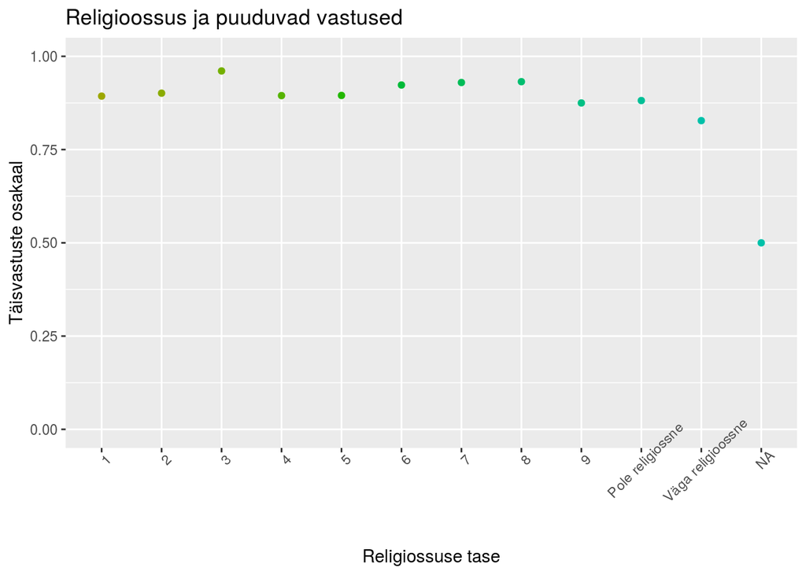

Kui me jätame välja 6 inimest, kellel on religioossuse tulp NA, siis kodeerides religioossuse taseme numbriliseks (Not at all religious = 0 ja Very religious = 10), siis näeme, et nende inimeste seas, kellel pole ühtegi puudulikku väärtust, on keskmine religioossus 3.3 ja nende seas kellel on puudulikke väärtusi, 3.2.

Puuduvate väärtuste ja religioossuse suhe 2

| Valiidsus | Keskmine religioossus |
| --- | --- |
| 0 | 3.156250 |
| 1 | 3.282532 |

Vaadates Eestis sündimist, on näha, et nende seas, kes pole sündinud Eestis, on täielike vastuste osakaal madalam (83.6%), kui nende seas, kes on sündinud Eestis (90.7%).

Sünnikoha ja puuduvate väärtuste suhe

| Kas sündinud Eestis | Valiidsete osakaal |
| --- | --- |
| No | 0.8358779 |
| Yes | 0.9074300 |

Haridusaastaid vaadates on näha, et vähemate aastate puhul on pisut rohkem inimesi, kellel on puuduvaid väärtuseid.

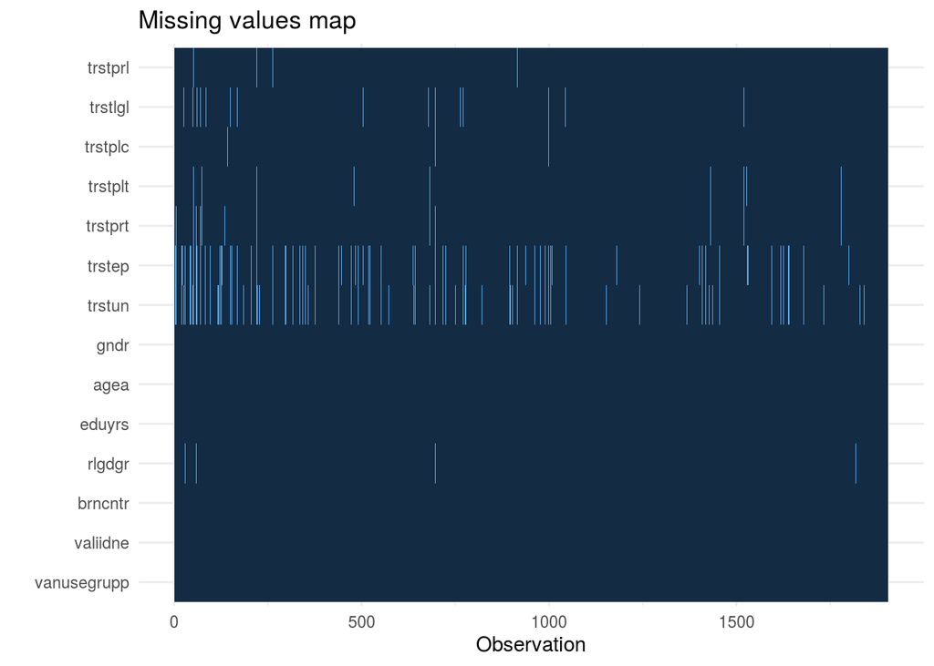

missing_pattern funktsioon näitab meile, kui palju erinevad puudu olemise mustreid on ja millised nad on. Näha on, et kõige rohkematel juhtudel pole puudu ühegi küsimuse vastust. Järgmisena on kõige tihemini puudu kaks vastust korraga: ÜRO ja Euroopa Liidu usaldamise küsimused. Süstemaatilisusele viitab nende kahe vastuse sagedane koos puudumine. Nad puuduvad sagedamini koos kui nad üksteisest eraldi puuduvad [eraldi: ÜRO 41 ja EU 19]. Isegi kokku teiste küsimustega puuduvate mustrite sageduste summa on väiksem. **Seega on selge, et väga tihti, kui puudub üks, siis puudub ka teine.** See võib olla selgitatav sellega, et mõlemad küsimused puudutavad rahvusvaheliseid organisatsioone. Nende küsimuste välja jätmisega paraneks täielike vastustega indiviidide osakaal märkimisväärselt, kuid kaoks ära rahvusvaheliste organisatsioonide usalduse uurimise võimalus.

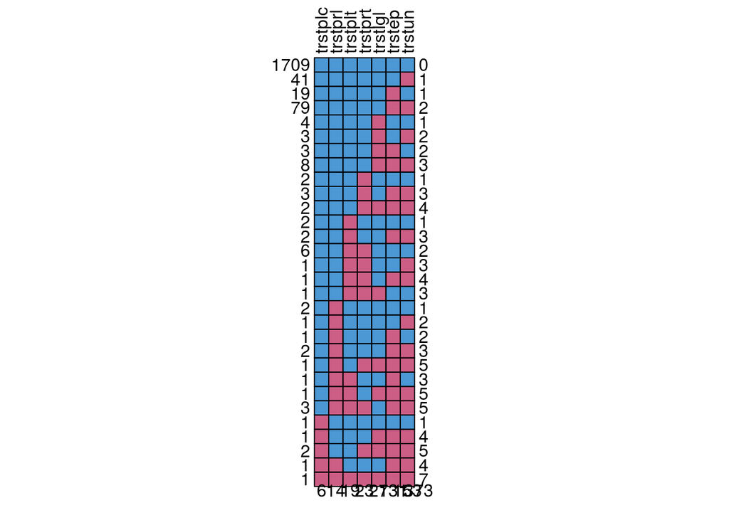

Näha on, et brutopalga (grspnum) tulbas 1061 puuduvat väärtust. Miinimum on 0 ja maksimum on 5000. Mediaan on 1050 ja keskmine on 1203. Mediaani ja keskmise erinemine viitab normaaljaotuse rikkumisele. Samuti on näha, et mediaan ja keskmine on miinimumväärtusele tunduvalt lähemal kui maksimumväärtusele. Saame arvutada välja erindite piiripunktid. Madalamas otsas ei saa olla erindeid, kõrgemas otsas on piiripunktiks 3025. Sellest punktist kõrgemaid väärtuseid on 28. Nendest 6 on äärmustlikud erindid, mille väärtus on üle 4450.

Brutopalga kirjeldavad statistikud

|  | Väärtus |
| --- | --- |
| nbr.val | 8.430000e+02 |
| nbr.null | 4.600000e+01 |
| nbr.na | 1.061000e+03 |
| min | 0.000000e+00 |
| max | 5.000000e+03 |
| range | 5.000000e+03 |
| sum | 1.014212e+06 |
| median | 1.050000e+03 |
| mean | 1.203098e+03 |
| SE.mean | 2.751566e+01 |
| CI.mean.0.95 | 5.400733e+01 |
| var | 6.382448e+05 |
| std.dev | 7.989023e+02 |
| coef.var | 6.640373e-01 |

```
##    Min. 1st Qu.  Median    Mean 3rd Qu.    Max.    NA's
##       0     650    1050    1203    1600    5000    1061
```

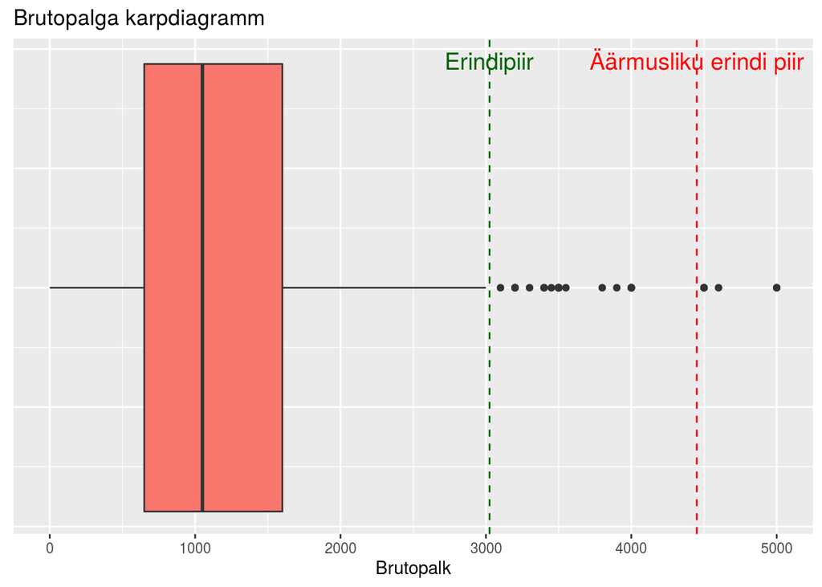

Erindite ja vanuse ning haridusaastate suhe

| Väärtuse tüüp | Keskmine vanus | Keskmised haridusaastad |
| --- | --- | --- |
| Puuduvad väärtused | 56.16305 | 12.82846 |
| Tavaväärtused | 44.02577 | 14.01472 |
| Äärmuslikud erindid | 41.50000 | 13.50000 |
| Erindid | 39.63636 | 16.22727 |